# 1. Loading of R packages: RCurl, ggplot2, extrafont, jsonlite, dplyr, tidyr, extrafont, jsonlite, reshape2, tm, wordcloud, SnowballC (R code not shown)

## 1. Loading of R packages: RCurl, ggplot2, extrafont, jsonlite, dplyr, tidyr, extrafont, jsonlite, reshape2, tm, wordcloud, SnowballC (R code not shown)

##Read df_state_avgStar in from Oracle

```r
df_state_avgStar <- data.frame(fromJSON(getURL(URLencode('129.152.144.84:5001/rest/native/?query="select * from state_avgstar"'),httpheader=c(DB='jdbc:oracle:thin:@129.152.144.84:1521:ORCL',USER='C##cs329e_jz7674',PASS='orcl_jz7674',MODE='native_mode',MODEL='model',returnDimensions = 'False',returnFor = 'JSON'),verbose = TRUE)))
head(df_state_avgStar)
```

```
##   STATE AVG_STAR
## 1   SCB 4.000000
## 2   NTH 2.000000
## 3    MN 5.000000
## 4    CA 3.333333
## 5   MLN 3.829268
## 6    WI 3.643601
```

##Beautiful bubble plot (R code not shown)

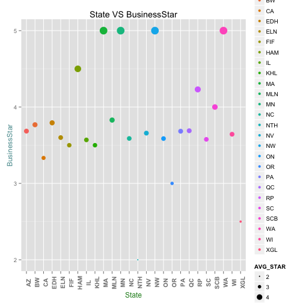

```r
df_state_avgStar %>% ggplot(aes(x=STATE,y=AVG_STAR, color=STATE,size=AVG_STAR)) + geom_point() + theme(axis.text.x=element_text(angle=90, size=20, vjust=0.5)) + theme(axis.text.x=element_text(size=10, face="bold", vjust=1)) + theme(axis.title.x=element_text(color="forestgreen", vjust=0.35),axis.title.y=element_text(color="cadetblue", vjust=0.35)) + labs(title="State VS BusinessStar",y="BusinessStar",x="State")
```

```r
names(df_state_avgStar) = gsub("\\.", "", names(df_state_avgStar))
rPlot(AVG_STAR ~ STATE, data = df_state_avgStar, color = 'STATE', type = 'point')
```

[output not shown]

## Text mining for AZ (About 20K reviews)

```r
# read the file in
AZ_review_text_tb <- read.csv("~/Desktop/Yelp Project/Yelp_project_review_dataset/AZ_REVIEWTEXT_DATA_TABLE.csv")
# turn the object into Corpus, a special object in r
AZ_text <- Corpus(VectorSource(AZ_review_text_tb$TEXT))
AZ_text <- tm_map(AZ_text, stripWhitespace) # remove white spaces
AZ_text <- tm_map(AZ_text, tolower) # convert to lower
AZ_text <- tm_map(AZ_text, removeWords, stopwords('english')) # remove common English words such as 'a', 'an'
AZ_text <- tm_map(AZ_text, removeWords, c('the')) # remove word "the"
```

##Create a word cloud for AZ

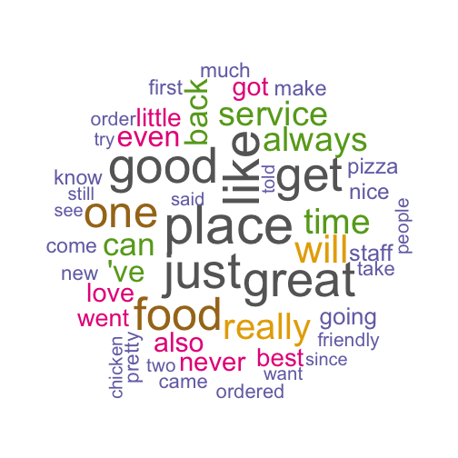

```r
wordcloud(AZ_text, scale=c(5,0.5), max.words=50, random.order=FALSE, rot.per=0.1, use.r.layout=FALSE, colors=brewer.pal(8, 'Dark2'))
```

## Text mining for PA

```r
PA_review_text_tb <- read.csv("~/Desktop/Yelp Project/Yelp_project_review_dataset/PA_REVIEWTEXT_DATA_TABLE.csv")
PA_text <- Corpus(VectorSource(PA_review_text_tb$TEXT))
PA_text <- tm_map(PA_text, stripWhitespace)
PA_text <- tm_map(PA_text, tolower)
PA_text <- tm_map(PA_text, removeWords, stopwords('english'))
PA_text <- tm_map(PA_text, removeWords, c('the'))
```

## Create a word cloud for PA

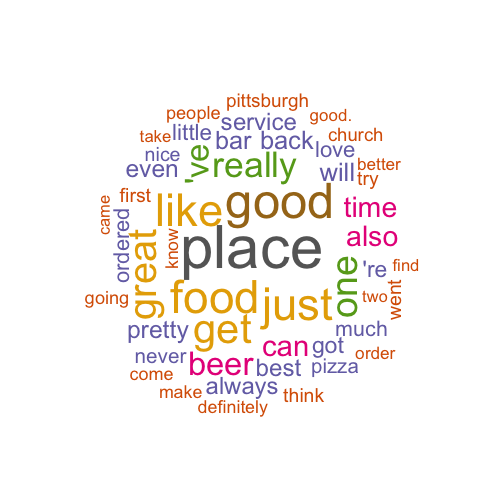

```r
wordcloud(PA_text, scale=c(5,0.5), max.words=50, random.order=FALSE, rot.per=0.1, use.r.layout=FALSE, colors=brewer.pal(8, 'Dark2'))
```

## Text mining for NV (About 10K reviews) In order to compare with AZ

```r
NV_review_text_tb <- read.csv("~/Desktop/Yelp Project/Yelp_project_review_dataset/NV_REVIEWTEXT_DATA_TABLE.csv")
NV_text <- Corpus(VectorSource(NV_review_text_tb$TEXT))
NV_text <- tm_map(NV_text, stripWhitespace)
NV_text <- tm_map(NV_text, tolower)
NV_text <- tm_map(NV_text, removeWords, stopwords('english'))
NV_text <- tm_map(NV_text, removeWords, c('the'))
```

##Create a word cloud for NV

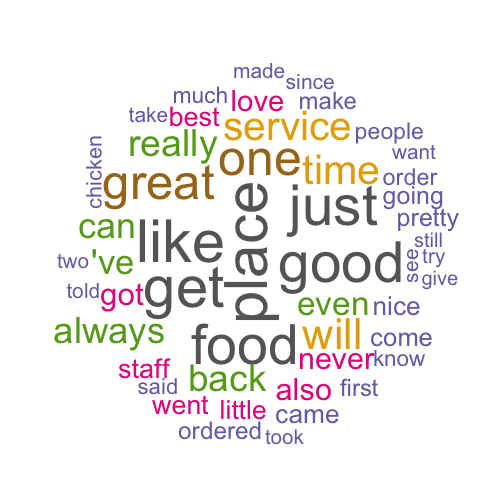

```r
wordcloud(NV_text, scale=c(5,0.5), max.words=50, random.order=FALSE, rot.per=0.1, use.r.layout=FALSE, colors=brewer.pal(8, 'Dark2'))
```

## Next we are interested in some small cities and want to see what we can find from these smaller samples. We draw a sample of review text from Charlotte, NC (About 1K reviews).

```r
NC_review_text_tb <- read.csv("~/Desktop/Yelp Project/Yelp_project_review_dataset/NC_REVIEWTEXT_DATA_TABLE.csv")
NC_text <- Corpus(VectorSource(NC_review_text_tb$TEXT))
NC_text <- tm_map(NC_text, stripWhitespace)
NC_text <- tm_map(NC_text, tolower)
NC_text <- tm_map(NC_text, removeWords, stopwords('english'))
NC_text <- tm_map(NC_text, removeWords, c('the'))
```

## Create a word cloud for NC

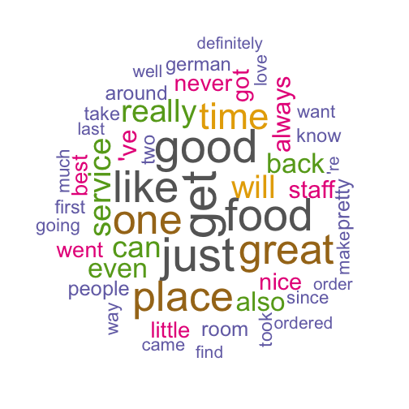

```r
wordcloud(NC_text, scale=c(5,0.5), max.words=50, random.order=FALSE, rot.per=0.35, use.r.layout=FALSE, colors=brewer.pal(8, 'Dark2'))
```

### An interesting thing to me is that the word 'german' is frequently used word. Then I guess there should be many german businesses in Charlotte. I googled this Q and found some info to back up my guess. “There are 194 German-owned firms in Charlotte USA including 59 U.S. headquarters; making Germany the most largely represented foreign country in the region…”(http://charlotteusa.com/business-info/international-business/germany)

## Back to AZ. Finally we want to focus our study on AZ

### Hierarchical Clustering Analysis for frequently used terms in AZ

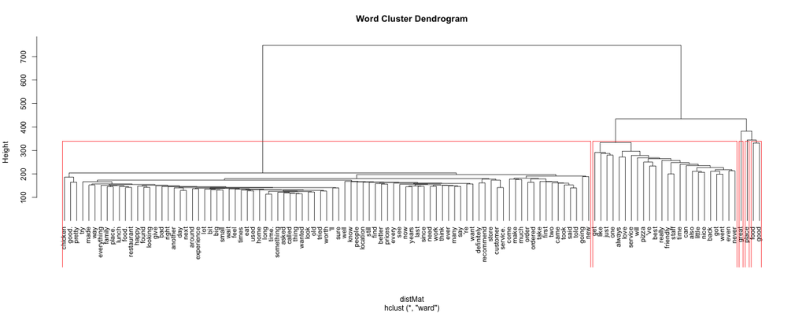

```r
AZ_text_tmDoc <- TermDocumentMatrix(AZ_text,control=list(wordLength=c(1,Inf)))
# AZ_text_tmDoc.TmDoc
# dimnames(AZ_text_tmDoc)$Terms
# findFreqTerms(AZ_text_tmDoc,highfreq=20)
AZ_text.tdm2 <- removeSparseTerms(AZ_text_tmDoc,sparse = 0.95)
AZ_text.mat2 <- as.matrix(AZ_text.tdm2)
distMat <- dist(scale(AZ_text.mat2))
AZ_text.fit <- hclust(distMat,method='ward')
plot(AZ_text.fit,cex=0.9,hang=-1,main='Word Cluster Dendrogram')
rect.hclust(AZ_text.fit,k=5)
```

### Hierarchical Clustering Analysis for frequently used terms in NV

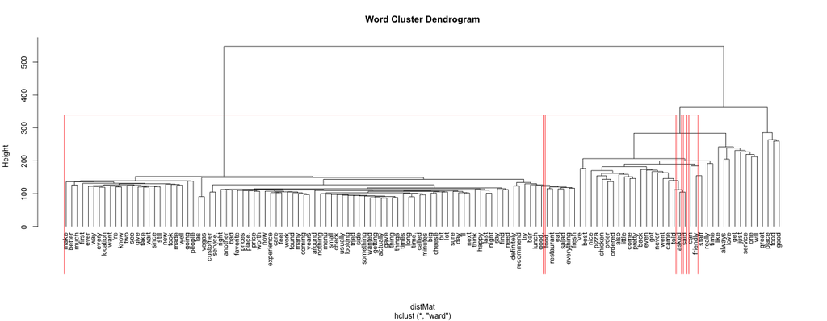

```r
NV_text_tmDoc <- TermDocumentMatrix(NV_text,control=list(wordLength=c(1,Inf)))
NV_text.tdm2 <- removeSparseTerms(NV_text_tmDoc,sparse = 0.95)
NV_text.mat2 <- as.matrix(NV_text.tdm2)
distMat <- dist(scale(NV_text.mat2))
NV_text.fit <- hclust(distMat,method='ward')
plot(NV_text.fit,cex=0.9,hang=-1,main='Word Cluster Dendrogram')
rect.hclust(AZ_text.fit,k=5)
```

### Discussion:

### 1. We could infer that, overall or on AVG, people in AZ like pizza better than chicken and there seems to be more pizza-realted business in AZ.

### 2. Ovrall or on AVG, pizza-realted businesses have better customer service (always, love, friendly,service) than chicken-realted business or restaurants (recommended, customer, service)

### Conclusion: 1. In AZ, Future business attention of chicken-related business are likely to focus on improving the customer service so that they are very likely to get better reviews and more reviews.

### 2. In AZ, it is likely that there are going to be more investment on AZ's pizza-related business from what we have inferred.